# Assignment 2

Rahul Jadhav

1/25/2022

## Data Preparation

For performing Chi square we created a new variable called SalePrice_ntile and used “quantcut” to creating a factor variable using the quantiles of a continuous variable called Sale Price.

```r
x<- quantile(main_dataset$SalePrice, probs = c(0, 0.20, 0.40, 0.60, 0.80, 1))
x
```

```
      0%    20%    40%    60%    80%   100%
   12789 124000 146500 178536 230000 755000
```

```r
main_dataset$SalePrice_ntile <- quantcut(main_dataset$SalePrice,5)
levels(main_dataset$SalePrice_ntile) <- c("q1","q2","q3","q4","q5")
summary(main_dataset$SalePrice_ntile)
```

```
   q1  q2  q3  q4  q5
  596 580 582 593 579
```

## Question-1 Chi-Square Test:

Performing Chi-Square test to examine if Sale Price varies by Neighborhood

H0 (null hypothesis) -> There is no relationship between Sale Price and Neighborhood H1 (Alternative Hypothesis) -> There is a relationship between Sale Price and Neighborhood

```r
options(width = 100)

# Chi Square Testing:  Whether Sale Price  is dependent on Neighborhood
myChisq <- xtabs(~ SalePrice_ntile + Neighborhood, data = main_dataset)
myChisq
```

```
                 Neighborhood
  SalePrice_ntile Blmngtn Blueste BrDale BrkSide ClearCr CollgCr Crawfor Edwards Gilbert Greens
               q1       0       5     28      52       1       9       5      94       1      0
               q2       0       1      2      34       4      39      15      55       3      0
               q3       8       2      0      13       8      38      20      24      61      2
               q4      16       2      0       9      14     120      32      12      84      6
               q5       4       0      0       0      17      61      31       9      16      0
                 Neighborhood
  SalePrice_ntile GrnHill IDOTRR Landmrk MeadowV Mitchel NAmes NoRidge NPkVill NridgHt NWAmes OldTown
               q1       0     65       0      32       9    95       0       2       0      2     133
               q2       0     19       1       4      38   177       0      14       0      9      60
               q3       0      7       0       1      40   125       0       7       6     49      32
               q4       1      2       0       0      17    34       2       0      26     53       8
               q5       1      0       0       0      10    12      69       0     134     18       6
                 Neighborhood
  SalePrice_ntile Sawyer SawyerW Somerst StoneBr SWISU Timber Veenker
               q1     36      11       0       0    16      0       0
               q2     67      17       4       1    15      1       0
               q3     43      30      37       1    13     12       3
               q4      5      48      58      11     4     22       7
               q5      0      19      83      38     0     37      14
```

```r
summary(as.factor(main_dataset$Neighborhood))
```

```
  Blmngtn Blueste  BrDale BrkSide ClearCr CollgCr Crawfor Edwards Gilbert  Greens GrnHill  IDOTRR
       28      10      30     108      44     267     103     194     165       8       2      93
  Landmrk MeadowV Mitchel   NAmes NoRidge NPkVill NridgHt  NWAmes OldTown  Sawyer SawyerW Somerst
        1      37     114     443      71      23     166     131     239     151     125     182
  StoneBr   SWISU  Timber Veenker
       51      48      72      24
```

```r
# Merging data with frequency lesser than 50 and changed its value as others
main_dataset$Neighborhood[main_dataset$Neighborhood == "Greens" |
                          main_dataset$Neighborhood == "GrnHill" |
                          main_dataset$Neighborhood == "Landmrk" |
                          main_dataset$Neighborhood == "Blueste" |
                          main_dataset$Neighborhood == "Blmngtn" |
                          main_dataset$Neighborhood == "BrDale" |
                          main_dataset$Neighborhood == "ClearCr" |
                          main_dataset$Neighborhood == "MeadowV" |
                          main_dataset$Neighborhood == "NPkVill" |
                          main_dataset$Neighborhood == "SWISU" |
                          main_dataset$Neighborhood == "Veenker" ] <- "Other"

myChisq <- xtabs(~ SalePrice_ntile + as.factor(Neighborhood), data = main_dataset)
myChisq
```

```
                 as.factor(Neighborhood)
  SalePrice_ntile BrkSide CollgCr Crawfor Edwards Gilbert IDOTRR Mitchel NAmes NoRidge NridgHt NWAmes
               q1      52       9       5      94       1     65       9    95       0       0      2
               q2      34      39      15      55       3     19      38   177       0       0      9
               q3      13      38      20      24      61      7      40   125       0       6     49
               q4       9     120      32      12      84      2      17    34       2      26     53
               q5       0      61      31       9      16      0      10    12      69     134     18
                 as.factor(Neighborhood)
  SalePrice_ntile OldTown Other Sawyer SawyerW Somerst StoneBr Timber
               q1     133    84     36      11       0       0      0
               q2      60    41     67      17       4       1      1
               q3      32    44     43      30      37       1     12
               q4       8    50      5      48      58      11     22
               q5       6    36      0      19      83      38     37
```

```r
tidy(chisq.test(myChisq))%>%
  select(
    method,
    DF = parameter,
    p.value,
    statistic
  )%>%
  mutate(
    statistic = round(statistic,2)
  )
```

```
  # A tibble: 1 x 4
    method                        DF p.value statistic
    <chr>                      <int>   <dbl>     <dbl>
  1 Pearson's Chi-squared test    68       0     2385.
```

Findings : When performed Chi-square test for the first time, i was constantly getting warning message as ” Chi-squared approximation may be incorrect”. This was due to few neighborhood frequencies where below 50. So i merged the neighborhood with frequency below 50 and called the variable as others.

Since the p.value is very significant, we will reject the null hypothesis.

## Question-2 ANOVA Test:

Performing ANOVA test to examine if Sale Price varies by Neighborhood and Exterior.

H0(null hypothesis) -> * Neighborhood and exterior of the house has no effect on Sale Price. Also there is no interaction affect on sale Price due to Neighborhood and Exterior.

H1(Alternative Hypothesis) -> * Neighborhood and exterior of the house has effect on Sale Price. Also there is interaction affect on sale Price due to Neighborhood and Exterior.

```r
two_way_fit <- aov(SalePrice ~ (Neighborhood) * Exterior.1st, data=main_dataset)
tidy(two_way_fit)%>%
  mutate(
    sumsq = signif(sumsq, digits = 2),
    p.value = round(p.value,3),
    statistic = round(statistic,3)

  )
```

```
  # A tibble: 4 x 6
    term                         df  sumsq        meansq statistic p.value
    <chr>                     <dbl>  <dbl>         <dbl>     <dbl>   <dbl>
  1 Neighborhood                 17 1  e13 592125571186.    242.         0
  2 Exterior.1st                 15 3.4e11  22598363602.      9.25       0
  3 Neighborhood:Exterior.1st   118 1.5e12  12670254173.      5.18       0
  4 Residuals                  2779 6.8e12   2444165870.     NA         NA
```

Interpretation : A two-way ANOVA was performed to analyze the effect of Neighborhood and Exterior Covering of house on Sale Price. A two-way ANOVA revealed that - Simple main effects analysis showed that Neighborhood did have a statistically significant effect on Sale Price (p = 0).

Simple main effects analysis showed that Exterior covering did have a statistically significant effect on Sale Price (p = 0).

## Interaction Plot from ANOVA

```r
unique(main_dataset$Neighborhood)
```

```
   [1] "NAmes"   "Gilbert" "StoneBr" "NWAmes"  "Somerst" "Other"   "NridgHt" "NoRidge" "SawyerW"
  [10] "Sawyer"  "BrkSide" "OldTown" "IDOTRR"  "Edwards" "CollgCr" "Crawfor" "Mitchel" "Timber"
```

```r
unique(main_dataset$Exterior.1st)
```

```
   [1] "BrkFace" "VinylSd" "Wd Sdng" "CemntBd" "HdBoard" "Plywood" "MetalSd" "AsbShng" "WdShing"
  [10] "Stucco"  "AsphShn" "BrkComm" "CBlock"  "PreCast" "Stone"   "ImStucc"
```

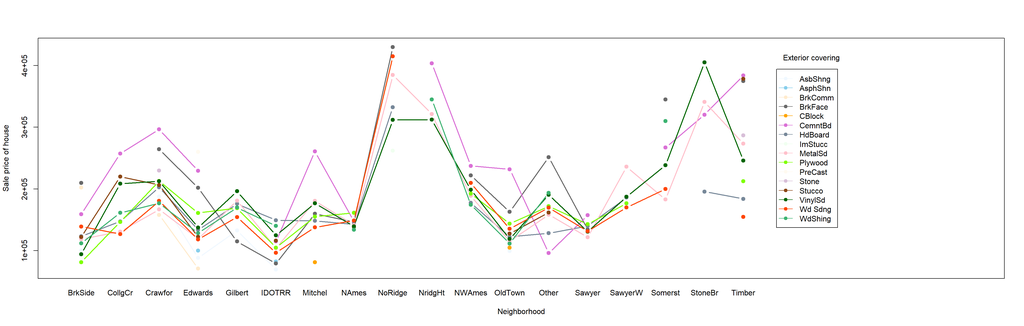

```r
## merging Exterior values lesser than 60
test <- main_dataset
test$Exterior.1st[test$Exterior.1st == "AsbShng"|
                    test$Exterior.1st == "AsphShn"|
                    test$Exterior.1st == "BrkComm"|
                    test$Exterior.1st == "CBlock"|
                    test$Exterior.1st == "ImStucc"|
                    test$Exterior.1st == "PreCast"|
                    test$Exterior.1st == "Stone"|
                    test$Exterior.1st == "Stucco"|
                    test$Exterior.1st == "WdShing"] <- "Other"


cols <- c("Alice Blue",
                         "Sky Blue",
                         "Blanched Almond",
                         "Dim Gray",
                         "Orange",
                         "Orchid",
                         "Light Slate Gray",
                         "Honeydew",
                         "Pink",
                         "Chartreuse",
                         "Floral White",
                         "Thistle",
                         "Saddle Brown",
                         "Dark Green",
                         "Orange Red",
                         "Medium Sea Green")
interaction.plot(x.factor = main_dataset$Neighborhood,
                 trace.factor = main_dataset$Exterior.1st,
                 response = main_dataset$SalePrice,
                 fun = mean,
                 type = "b",
                 ylab = "Sale price of house",
                 xlab = "Neighborhood",
                 col = cols,
                 lty = 1, #line type
                 lwd = 2, #line width
                 trace.label = "Exterior covering",
                 pch=c(19),             ### Symbols for levels of trace var.
                 fixed=TRUE,                    ### Order by factor order in data
                 leg.bty = "o")
```

Interpretation :

<> We can see from the above plot that there is a lot of interaction between neighborhood and exterior covering

<> We can learn from 2 way anova that the pvalue is below 0.05 which is significant and we can reject our null hypothesis.

## Conclusion

<>Using chi-sqaure we will reject our null hypothesis because there is relationship between Sale Price and neighborhood <>Using Anova 2 way test we will reject our null hypothesis because there is relationship between Sale Price and neighborhood and exterior covering and also there is interaction affect on sale price due to neighborhood and exterior

## Reference

<>Team, D. (2021, August 25). Chi-Square Test in R | Explore the Examples and Essential concepts! DataFlair. https://data-flair.training/blogs/chi-square-test-in-r/

<>Two-way ANOVA Output and Interpretation in SPSS Statistics - Including Simple Main Effects | Laerd Statistics. (n.d.). Laerd Statistic. https://statistics.laerd.com/spss-tutorials/two-way-anova-using-spss-statistics-2.php